# dataset simulations

Shen Cheng

2021-07-01

# 1. Descriptions

- In this section, we will illustrate how to simulate a population dataset using `mrgsolve` using a PK-PD model
- Scienrio:
  - A hypothetical Drug A is administered orally
  - Drug A can inhibit the synthesis of hypothetical soluble protein B
  - Following administration, drug A exhibits a delayed absorption and mono-exponential elimination
  - Concentrations of drug A and protein B are measurable in plasma
  - Genotype C can impact the elimination of drug A
    - intermediate metabolizors (IM) exhibit 50% reduction in drug A clearance compared with extensive metabolizors (EM)
    - poor metabolizors (PM) exhibit 80% reduction in drug A clearance compared with extensive metabolizors (EM)
  - Drug A also exhibits a age-dependent decrease in clearance
  - Gender can impact the synthesis rate of protein B
- `mrgsolve` model file is shown below

```r
pkpd_model <- '

[set] delta = 0.01, end = 50

[PROB]
 - author: Shen Cheng
 - date: `r Sys.Date()`
 - comments: this is a demonstration
 - PK: one compartment model + transit compartment absportion + first order elimination
 - PD: indirect response model with drug inhibiting `kin`
 - allometric scaling on flow and volume based parameters
 - random effects added on `ktr`, `cl`, `vc`, `ic50` and `kin` as exponential distributions
 - proportional error model
 - model covariates: geno ~ cl, age ~ cl and sex ~ kin

[PARAM] @annotated
tvcl    :  1   : typical value of clearance (L/hr)
tvvc    :  20  : typical value of central volume of distribution (L)
tvktr   :  1   : typical value of transit rate (/hr)
tvic50  :  1   : typical value of concentration which introduce 50% of inhibitory effects (mg/L)
tvkin   :  50  : synthetic rate (/hr)
tvkout  :  5   : degradation rate (/hr)
geno2cl :  0.5 : genotype 2 effect on cl (IM)
geno3cl :  0.2 : genotype 3 effect on cl (PM)
agecl   :  -0.3: age effect on cl
sexkin  :  0.8 : sex effect on kin
geno    :  1   : reference genotype (extensive metabolizor: 1/intermediate metabolizor: 2/poor metabolizor: 3)
age     :  50  : reference age (years)
sex     :  0   : reference gender (female: 0/male: 1)
wt      :  70  : refernce wt (kg)

[CMT]  @annotated
depot  : depot compartment (mass)
trans1 : transit compartment 1 (mass)
trans2 : transit compartment 2 (mass)
trans3 : transit compartment 3 (mass)
cent   : central compartment (mass)
resp   : response compartment (conc)

[MAIN]
double cl = tvcl*pow(wt/70, 0.75)*pow(age/50, agecl)*exp(ETA(1));
  if (geno == 2) cl = tvcl*pow(wt/70, 0.75)*pow(age/50, agecl)*exp(ETA(1))*geno2cl;
  if (geno == 3) cl = tvcl*pow(wt/70, 0.75)*pow(age/50, agecl)*exp(ETA(1))*geno3cl;
double vc = tvvc*pow(wt/70,1)*exp(ETA(2));
double ktr = tvktr*exp(ETA(3));
double ic50 = tvic50*exp(ETA(4));
double kin = tvkin*pow(sexkin, sex)*exp(ETA(5));
double kout = tvkout;

resp_0 = kin/kout; //initialize the response compartment at steady state

[OMEGA] @annotated @correlation
iivcl : 0.1 : interindividual variability (iiv) on cl
iivvc : 0.5 0.2 : iiv on vc (50% correlation between cl and vc)

[OMEGA] @annotated
iivktr  : 0.1 : iiv on ktr
iivic50 : 0.3 : iiv on ic50
iivkin  : 0.2 : iiv on kin

[SIGMA] @annotated
ruvpk   : 0.01 : ruv on pk obs
ruvpd   : 0.04 : ruv on pd obs

$ODE
//PK
double cp = cent/vc;

dxdt_depot = -ktr*depot;
dxdt_trans1 = ktr*(depot - trans1);
dxdt_trans2 = ktr*(trans1 - trans2);
dxdt_trans3 = ktr*(trans2 - trans3);
dxdt_cent  = ktr*trans3 - cl*cp;

//PD
double inh = cp /(cp + ic50);
double res = resp;

dxdt_resp = kin*(1-inh) - kout*resp;

[TABLE]
double pkobs = cp*(1 + EPS(1));
double pdobs = resp*(1 + EPS(2));

$CAPTURE
cp, res, pkobs, pdobs

'
```

# 2. Study design

- Single dose study
- 100 subjects were recruited following the informed consent
- One pre-dose blood sample was collected from each subject to assess the baseline concentration of protein B
- Drug A is administered orally as either 50, 100 or 200 mg tablet
- Blood samples were then collected at 0.5, 1, 2, 4, 8, 12, 24, 48 hours post-dose
- Plasma concentrations of drug A and protein B were meausred

# 3. Simulations

```r
library(mrgsolve)
library(tidyverse)
library(ggpubr)
library(truncnorm) #functionality related to truncated nomral distribution
library(reshape2)  #reshape long/wide dataset: melt/dcast
library(lubridate) #date and clocktime calculations
```

## 3.1 Create dataset for simulation

- First, let's create a dataset (intervention + population) for simulation
  - The dataset contains 100 subjects
  - Each subject receives either 50, 100 or 200 mg of drug A orally
  - Subjects' `genotype` (geno, 1: EM/2: IM/3: PM), `age` (in years), `sex` (0: female/1: male), `ethnicity` (0: hispanic/1: non-hispanic), `weight` (wt, in kg), `height` (ht, in cm), `creatine clearance` (crcl, in ml/min) were collected
  - Remainder: `weight`, `height` and `creatine clearance` normally correlate with sex

```r
set.seed(0720) #set a seed for reproducibilty
data <-
  data.frame(ID = 1:100,                                              #100 subjects
             amt = sample(c(50,100,200),replace = TRUE, size=100),    #sample 100 doses from c(50, 100, 200) with replacement
             cmt = 1,                                                 #dose in compartment 1
             evid = 1,                                                #event id 1: dose event
             time = 5,                                                #non-zero dose time to accommodate predose sample
             geno = sample(c(1,2,3), replace = TRUE, size=100),       #genotype (1: EM/2: IM/3: PM)
             age = rtruncnorm(n=100, a=0, b=Inf, mean=50, sd=5),      #age (trunc N(50,5) (lower bound 0)
             sex = sample(c(0,1), replace = TRUE, size=100),          #sex (0: female/1: male)
             ethnicity = sample(c(0,1), replace = TRUE, size=100)     #ethnicity (0: hispanic/1: non-hispanic)
  )

#generate weight (wt), height (ht) and creatine clearance (crcl)
#assuming these parameters are correlated with sex

output <- data.frame(NULL)

for (i in 1:100){
  temp <- subset(data, ID == i)  #subset one individual for one time
  temp <-
    temp %>%
    mutate(wt = if_else(sex == 0,
                        rtruncnorm(n=1, a=0, b=Inf, mean=60, sd=10), #wt female (trunc N(60,10) (lower bound 0) (kg)
                        rtruncnorm(n=1, a=0, b=Inf, mean=70, sd=10)) #wt male (trunc N(70,10) (lower bound 0) (kg)
           ) %>%
    mutate(ht = if_else(sex == 0,
                        rtruncnorm(n=1, a=0, b=Inf, mean=160, sd=10), #ht female (trunc N(160,10) (lower bound 0) (cm)
                        rtruncnorm(n=1, a=0, b=Inf, mean=175, sd=10)) #ht male (trunc N(175,10) (lower bound 0) (cm)
           ) %>%

    mutate(crcl = if_else(sex == 0,
                          rtruncnorm(n=1, a=0, b=Inf, mean=115, sd=10), #crcl female (trunc N(115,10) (lower bound 0) (ml/min)
                          rtruncnorm(n=1, a=0, b=Inf, mean=130, sd=10)) #crcl male (trunc N(130,10) (lower bound 0) (ml/min)
           )
  output <- rbind(output, temp) #row bind temp dataset after processing
}

data <- output
```

- We can check the dataset created to see if anything out of our expectation

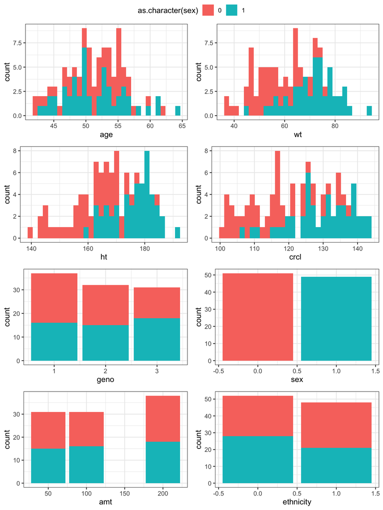

```r
plot_hist <- function(column){   #create a function for continous covariate exploration
  column = enquo(column)   #Identify arguments referring to data frame columns directly.
                           #quote these arguments
                           #!!: unquote arguments later inside the plot step

  data %>%
  ggplot() +
  geom_histogram(aes(x=!!column, fill=as.character(sex)), bins=30)+ #plot as histogram, bins sets bin bumber
  theme_bw()
}

plot_bar <- function(column){    #create a function for categorical covariate exploration
  column = enquo(column)

  data %>%
  ggplot() +
  geom_bar(aes(x=!!column, fill=as.character(sex)))+   #plot as barplot
  theme_bw()
}

p1 <- plot_hist(age)
p2 <- plot_hist(wt)
p3 <- plot_hist(ht)
p4 <- plot_hist(crcl)
p5 <- plot_bar(geno)
p6 <- plot_bar(sex)
p7 <- plot_bar(amt)
p8 <- plot_bar(ethnicity)

ggarrange(p1, p2, p3, p4, p5, p6, p7, p8, ncol = 2, nrow = 4, common.legend = TRUE)
```

## 3.2 Simulation with `mrgsolve`

- Using the dataset created (intervention + population), we can start our simulation

```r
pkpd <- mcode("pkpd_model", pkpd_model) #read model in using mcode
```

```
## Building pkpd_model ... done.
```

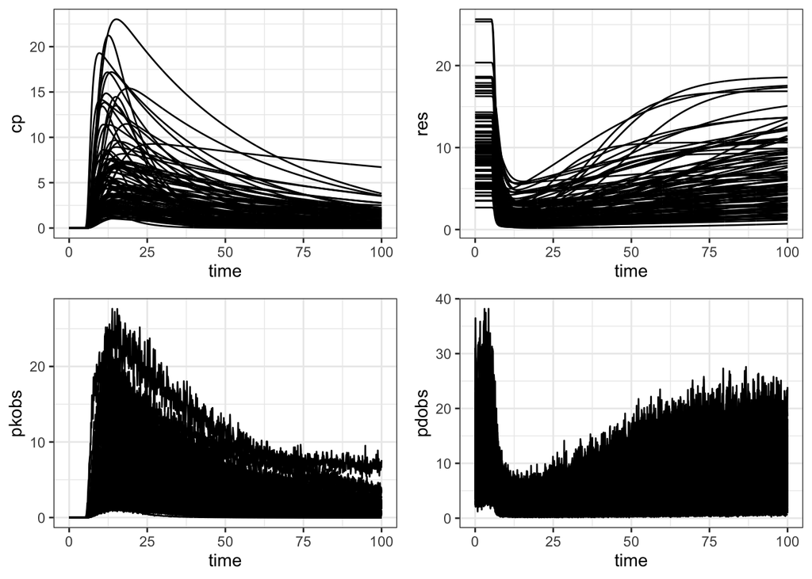

```r
set.seed(0720)
sim <-
  pkpd %>%
  data_set(data) %>%
  mrgsim(end=100, delta=0.1, tad=TRUE, obsonly=TRUE) %>% #`tad=TRUE` allows the calculation of the "time after dose"
  as.data.frame()

plot_sim <- function(data, column){
  column <- enquo(column)

  data %>%
  ggplot(aes(x=time, y=!!column, group=ID))+
  geom_line()+
  theme_bw()
}

p9 <- plot_sim(data=sim, column=cp)
p10 <- plot_sim(data=sim, column=res)
p11 <- plot_sim(data=sim, column=pkobs)
p12 <- plot_sim(data=sim, column=pdobs)

ggarrange(p9, p10, p11, p12, ncol=2, nrow=2)
```

## 3.3 sample observations out of simulations

- We have simulated a large dataset contains 1001 observations for each individual!
- We will now select observations based on our study design

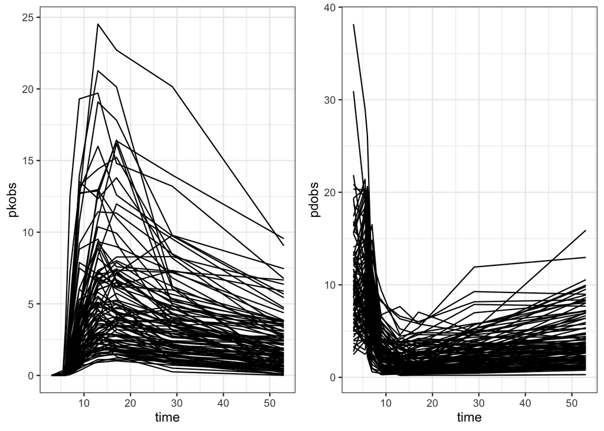

```r
obs <-
  sim %>%
  filter(tad %in% c(-2, 0.5, 1, 2, 4, 8, 12, 24, 48)) %>% #select datapoints based on study design from simulated dataset
  select(ID, time, tad, pkobs, pdobs) #only keep these five columns

#data check
p13 <-
  obs %>%
  ggplot(aes(x=time, y=pkobs, group=ID))+
  geom_line()+
  theme_bw()

p14 <-
  obs %>%
  ggplot(aes(x=time, y=pdobs, group=ID))+
  geom_line()+
  theme_bw()

ggarrange(p13, p14, ncol=2)
```

# 4. Further processing

## 4.1 Merge `observations`, `interventions` and `demographics`

- We now have a dataset contains all the observation `obs`
- And a dataset contains all the intervention and covariate information
- Let's merge these two datasets into one
  - `melt` and `dcast` are functions in package `reshape2`, they convert "wide dataset into long format" and "long dataset into wide format" respectively
  - `merge` is a very useful `base` R function, it helps merge two datasets into one based on their common columns

```r
obs_long <-
  melt(obs,                                  #dataset to reshape
       id.vars=c("ID", "time", "tad"),       #index variables
       variable.name = "type",               #name for new variable created
       value.name = "dv")                    #name for melted varible

obs_long <- obs_long %>% arrange(ID, time) %>% filter(dv != 0)  #sort dataset by ID and time
                                                                #remove pkobs pre-dose

df <- merge(data, obs_long, by=c("ID", "time"), all=TRUE) #merge dose record (data) and observation records
                                                          #by: set columns used for merging
                                                          #all: whether to keep unmatching rows

#df <- merge(data, obs_long, by=c("ID", "time"))
#df <- merge(data, obs_long, by=c("ID", "time"), all.x=TRUE) #all.x=TRUE will delete unmatching rows

df <-
  df %>% select(ID       , time, tad , dv  , amt,
                cmt      , evid, type, geno, sex,
                ethnicity, age , wt  , ht  , crcl)   #reorder columns
```

## 4.2 Fill in `NA`

- After merging two datasets, it is sometimes inevitable to have `NA` since some rows in dataset `x` don't have matching rows in dataset `y`
- Thus, we need to fill in these `NA` based on our expectation
  - `mutate(var = if_else())` is a useful syntax to use. It fills in information in one column based on the condition of certain columns in the dataset
  - `fill` in `tidyr` is also very useful. It fills in information based on the available information in a column and the direction specified
- I used to create some columns (such as `dose` and `bmi`) which I think maybe useful for further data processing, exploration and analysis at this step.

```r
#fill in NAs column by column
df <- df %>% mutate(tad = if_else(is.na(tad), 0, tad)) #set tad NA to 0
df <- df %>% mutate(dv = if_else(is.na(dv), 0, dv)) #set dv NA to 0
df <- df %>% mutate(amt = if_else(is.na(amt), 0, amt)) #set amt NA to 0
df <- df %>% mutate(cmt = if_else(type == "pkobs", 5, 6)) %>% mutate(cmt = if_else(is.na(cmt), 1, cmt)) #set cmt=1 for dose
                                                                                                        #set cmt=5 for pkobs
                                                                                                        #set cmt=6 for pdobs
df <- df %>% mutate(evid = if_else(is.na(evid), 0, evid)) #set evid NA to 0
df <- df %>% mutate(type = if_else(cmt == 6, 2, 1)) #set type for pk data as 1, for pd data as 2
df <- df %>% mutate(mdv = if_else(evid == 1, 1, 0)) %>% select(ID, time, tad , dv, amt, cmt, evid, mdv, everything())
#create mdv (missing dependent variable)
#everything() will include everything left so we don't need to type everything out

df <-
  df %>%
  group_by(ID) %>%
  fill(geno     , .direction = "downup") %>% #fill NA for each individual
  fill(sex      , .direction = "downup") %>% #downup: set fill direction middle out
  fill(ethnicity, .direction = "downup") %>%
  fill(age      , .direction = "downup") %>%
  fill(wt       , .direction = "downup") %>%
  fill(ht       , .direction = "downup") %>%
  fill(crcl     , .direction = "downup")

df <- df %>% group_by(ID) %>% mutate(dose = max(unique(amt))) #create dose column in convenience for plotting
df <- df %>% mutate(bmi = wt/((ht/100)^2)) #create bmi column (kg/m^2)

#keep 2 decimal places for all the continous cov
df <-
  df %>%
  mutate(age = round(age, digits=2),
         wt = round(wt, digits=2),
         ht = round(ht, digits=2),
         crcl = round(crcl, digits=2),
         bmi = round(bmi, digits=2)
         )
```

## 4.3 Simulate actual time

- In reality, it is extremely difficult to sample at exact time points as in the study protocol
- Thus, the actual sample time normally deviate a bit from the designed sample time
- We can simulate the actual sample time by sample a time difference between a synmetrical time range around 0
  - Here we assume a ± 0.2 hour time difference
- Then add up the simulated exact time and the time difference
  - `round` can be used to round up the decimal places after calculation

```r
output <- data.frame(NULL)

set.seed(0720)
for (i in unique(df$ID)){
  temp1 <- subset(df, ID == i)
  time_diff <- runif(length(unique(temp1$time)), min = -0.2, max = 0.2)  #sample time_diff U(-0.2, 0.2) (unit: hour)
  temp2 <- data.frame(time = unique(temp1$time), diff = time_diff) #create a dataframe with time and time_diff
  temp <- merge(temp1, temp2, by=c("time"), all.x=TRUE) #merge time_diff in
  output <- rbind(output, temp)
}

df <- output
df <- df %>% rename(nom_time = time, nom_tad = tad) #rename time and tad as nominal time and tad
df <- df %>% mutate(time = round(nom_time + diff, digits = 2), #create time = nom_time + time_diff, round to 2 decimal place
                    tad = round(nom_tad + diff, digits = 2)) #create tad = nom_tad + time_diff, round to 2 decimal place
df <- df %>% arrange(ID, time) %>% select(ID, time, tad, nom_time, nom_tad, diff, everything())
```

## 4.4 Simulate date and clock time

- In reality, sampling time may also be recorded as date and clock time.
- Here, we can simulate this using package `lubridate`
  - `as_date()` can convert days since `1970-01-01` into a date
  - `hms::as_hms()` can convert seconds since `00:00:00` into a clock time

```r
output <- data.frame(NULL)

for (i in 1:100){
  temp1 <- subset(df, ID == i)
  temp1 <-
    temp1 %>%
    mutate(date = runif(1, min=18700, max=18800)) %>%
    mutate(date = if_else(nom_tad > 38, date+2, #set dose time 10 am, if tad > 38 hr, add 2 days
                          if_else(nom_tad > 14, date+1, date)))  #if tad > 14 hr, add 1 day
  temp1 <-
    temp1 %>%
    mutate(clocktime = tad*3600+3600*10)%>%
    mutate(clocktime = if_else(nom_tad > 38, clocktime-3600*48, #set dose time 10 am, if tad > 38 hr, add 2 days (48hr*3600s)
                               if_else(nom_tad > 14, clocktime-3600*24, clocktime))) #if tad > 14 hr, add 2 days (24hr*3600s)

  output <- rbind(output, temp1)
}

output <-
  output %>%
  mutate(date = as_date(date), #function in `lubridate`, convert days to dates
         clocktime = hms::as_hms(clocktime)) #function in `lubridate`, convert seconds to clocktime

output <- output %>% select(ID, time, tad, nom_time, nom_tad, diff, date, clocktime, everything()) #reorder columns
output <- output %>% select(-time, -nom_time, -diff) #remove undesired columns
df <- output
```

## 4.5 Simulate missingness

- Again, in reality, we may not be able to sample such a complete dataset
- It is not uncommon that certain individuals miss a couple of samples
- We can simulate missingness with a `for` loop as shown below

```r
output <- data.frame(NULL)

set.seed(0720)
for (i in 1:100){
  temp <- subset(df, ID == i) #subset one individual at a time

  temp_dose <- subset(temp, amt != 0) #subset dose records for that individual

  temp_obs <- subset(temp, amt == 0) #subset observation records for that individual
  temp_obs <- temp_obs %>% mutate(index = type*1000+tad) #create a index column
  n <- sample(c(0,1,2,3), size=1) #randomly decide number of missing samples for an individual
  temp_obs <- temp_obs %>% filter(!(index %in% sample(unique(temp_obs$index), replace = FALSE, size=n))) #drop missing samples
  temp_obs <- temp_obs %>% select(-index) #delete index column

  temp_new <- rbind(temp_dose, temp_obs)
  output <- rbind(output, temp_new)
}

output <- output %>% arrange(ID, tad)
df <- output
```

# 5. Output

## 5.1 Check simulated dataset

- Now, a `NONMEM` dataset for fitting a PK-PD model has been simulated
- Let's check our simulated dataset a bit

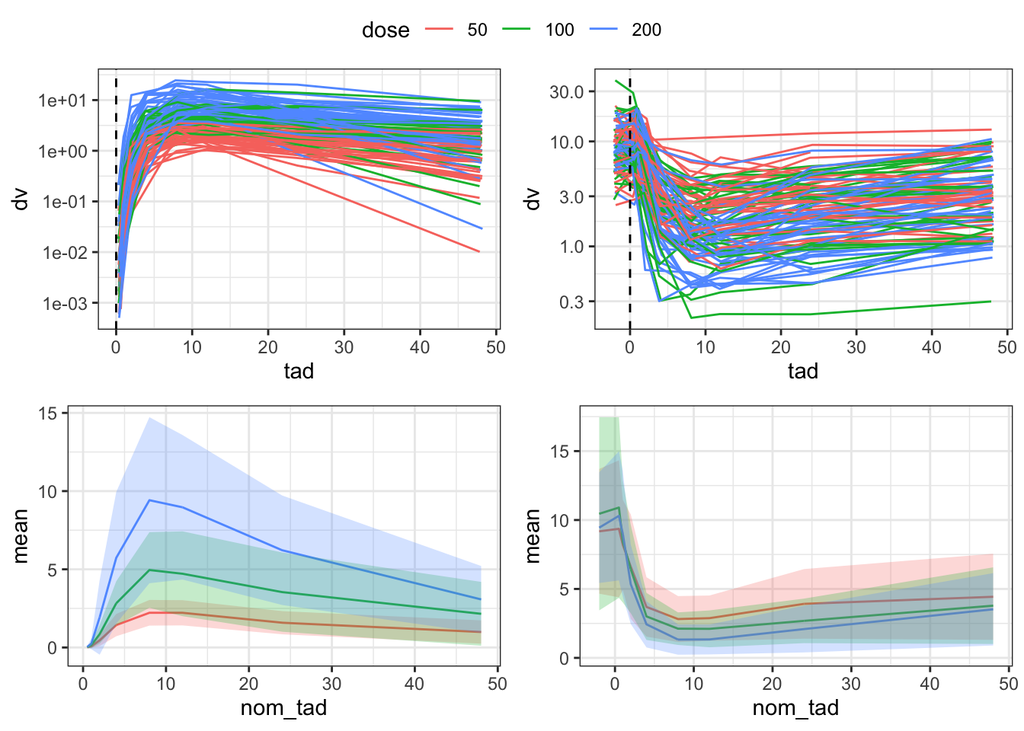

```r
p15 <-
  df %>%
  filter(cmt == 5) %>%
  mutate(dose = as.character(dose)) %>% #convert data structure
  mutate(dose = fct_relevel(dose, c("50", "100", "200"))) %>% #reorder data item
  ggplot(aes(x=tad, y=dv, group=ID, color=dose))+
  geom_line()+
  geom_vline(xintercept = 0, linetype=2)+ #add vertical line indicating dosing time
  theme_bw()+
  scale_y_log10()

p16 <-
  df %>%
  filter(cmt == 6) %>%
  mutate(dose = as.character(dose)) %>%
  mutate(dose = fct_relevel(dose, c("50", "100", "200"))) %>%
  ggplot(aes(x=tad, y=dv, group=ID, color=dose))+
  geom_line()+
  geom_vline(xintercept = 0, linetype=2)+
  theme_bw()+
  scale_y_log10()

p17 <-
  df %>%
  filter(cmt == 5) %>%
  group_by(dose, nom_tad) %>%
  mutate(mean = mean(dv), sd = sd(dv)) %>%
  ungroup() %>%
  mutate(dose = as.character(dose)) %>%
  mutate(dose = fct_relevel(dose, c("50", "100", "200"))) %>%
  ggplot()+
  geom_line(aes(x=nom_tad, y=mean, group=dose, color=dose))+
  geom_ribbon(aes(x=nom_tad, ymin=mean-sd, ymax=mean+sd, group=dose, fill=dose), alpha=0.25)+
  theme_bw()

p18 <-
  df %>%
  filter(cmt == 6) %>%
  group_by(dose, nom_tad) %>%
  mutate(mean = mean(dv), sd = sd(dv)) %>%
  ungroup() %>%
  mutate(dose = as.character(dose)) %>%
  mutate(dose = fct_relevel(dose, c("50", "100", "200"))) %>%
  ggplot()+
  geom_line(aes(x=nom_tad, y=mean, group=dose, color=dose))+
  geom_ribbon(aes(x=nom_tad, ymin=mean-sd, ymax=mean+sd, group=dose, fill=dose), alpha=0.25)+
  theme_bw()

ggarrange(p15, p16, p17, p18, ncol=2, nrow=2, common.legend = TRUE)
```

## 5.2 Output dataset

- At the end, we normally output our simulated dataset in to a `.csv` file for further use in `NONMEM`

```r
setwd("/Users/shencheng/Documents/GitHub/SummerSession2021/Session2_Simulations")
getwd()                                                          #confirm working directory before output

#Personally, I prefer to use "." instead of 0 in `dv` and `amt` columns
#Not required
df_output <-
  df %>%
  mutate(dv = round(dv, digits = 4)) %>%
  mutate(dv = as.character(dv)) %>%
  mutate(amt = as.character(amt)) %>%
  mutate(dv = if_else(dv == "0", ".", dv)) %>%
  mutate(amt = if_else(amt == "0", ".", amt))

#output dataset

write.csv(df_output, "r4pmx_dataset_simulation.csv", row.names = FALSE) #write.csv(data name in R, "output name.csv")
                                                                 #`row.names = FALSE` removes the line number column

#Can also use `write.table` here, but need to specfiy separations (eg. `sep=","`)
```